# CH7 : Principal component analysis

TP7 : Decathlon Data

Several functions from different packages are available in the `R` software for computing `PCA`:

- `prcomp()` and `princomp()` [built-in `R stats` package],
- `PCA()` [`FactoMineR` package],
- `dudi.pca()` [`ade4` package],
- `epPCA()` [`ExPosition` package].

No matter what function you decide to use, you can easily extract and visualize the results of `PCA` using `R` functions provided in the `factoextra` `R` package.

# Example 1 : Decathlon Data

## Question 1

install packages `FactoMineR` and factoextra and Load them in `R`

```r
library("FactoMineR")
library("factoextra")
```

## Question 2

Load the demo data sets `decathlon2` from the `factoextra` package using the data operator and show its first lines using head

```r
dec=data(decathlon2)
head(dec)
```

```
## [1] "decathlon2"
```

## Question 3

```r
str(dec)
```

```
##  chr "decathlon2"
```

[figure not shown]

In PCA terminology, our data contains :

- Active individuals (in light blue, rows 1:23) : Individuals that are used during the principal component analysis.
- Supplementary individuals (in dark blue, rows 24:27) : The coordinates of these individuals will be predicted using the PCA information and parameters obtained with active individuals/variables
- Active variables (in pink, columns 1:10) : Variables that are used for the principal component analysis.
- Supplementary variables: As supplementary individuals, the coordinates of these variables will be predicted also. These can be:
  - Supplementary continuous variables (red): Columns 11 and 12 corresponding respectively to the rank and the points of athletes.
  - Supplementary qualitative variables (green): Column 13 corresponding to the two athlete-tic meetings (2004 Olympic Game or 2004 Decastar). This is a categorical (or factor) variable factor. It can be used to color individuals by groups.

## Question 4

Extract only active individuals and variables:

```r
df=decathlon2[1:23, 1:10]
df
```

```
##             X100m Long.jump Shot.put High.jump X400m X110m.hurdle Discus
## SEBRLE      11.04      7.58    14.83      2.07 49.81        14.69  43.75
## CLAY        10.76      7.40    14.26      1.86 49.37        14.05  50.72
## BERNARD     11.02      7.23    14.25      1.92 48.93        14.99  40.87
## YURKOV      11.34      7.09    15.19      2.10 50.42        15.31  46.26
## ZSIVOCZKY   11.13      7.30    13.48      2.01 48.62        14.17  45.67
## McMULLEN    10.83      7.31    13.76      2.13 49.91        14.38  44.41
## MARTINEAU   11.64      6.81    14.57      1.95 50.14        14.93  47.60
## HERNU       11.37      7.56    14.41      1.86 51.10        15.06  44.99
## BARRAS      11.33      6.97    14.09      1.95 49.48        14.48  42.10
## NOOL        11.33      7.27    12.68      1.98 49.20        15.29  37.92
## BOURGUIGNON 11.36      6.80    13.46      1.86 51.16        15.67  40.49
## Sebrle      10.85      7.84    16.36      2.12 48.36        14.05  48.72
## Clay        10.44      7.96    15.23      2.06 49.19        14.13  50.11
## Karpov      10.50      7.81    15.93      2.09 46.81        13.97  51.65
## Macey       10.89      7.47    15.73      2.15 48.97        14.56  48.34
## Warners     10.62      7.74    14.48      1.97 47.97        14.01  43.73
## Zsivoczky   10.91      7.14    15.31      2.12 49.40        14.95  45.62
## Hernu       10.97      7.19    14.65      2.03 48.73        14.25  44.72
## Bernard     10.69      7.48    14.80      2.12 49.13        14.17  44.75
## Schwarzl    10.98      7.49    14.01      1.94 49.76        14.25  42.43
## Pogorelov   10.95      7.31    15.10      2.06 50.79        14.21  44.60
## Schoenbeck  10.90      7.30    14.77      1.88 50.30        14.34  44.41
## Barras      11.14      6.99    14.91      1.94 49.41        14.37  44.83
##             Pole.vault Javeline X1500m
## SEBRLE            5.02    63.19 291.70
## CLAY              4.92    60.15 301.50
## BERNARD           5.32    62.77 280.10
## YURKOV            4.72    63.44 276.40
## ZSIVOCZKY         4.42    55.37 268.00
## McMULLEN          4.42    56.37 285.10
## MARTINEAU         4.92    52.33 262.10
## HERNU             4.82    57.19 285.10
## BARRAS            4.72    55.40 282.00
## NOOL              4.62    57.44 266.60
## BOURGUIGNON       5.02    54.68 291.70
## Sebrle            5.00    70.52 280.01
## Clay              4.90    69.71 282.00
## Karpov            4.60    55.54 278.11
## Macey             4.40    58.46 265.42
## Warners           4.90    55.39 278.05
## Zsivoczky         4.70    63.45 269.54
## Hernu             4.80    57.76 264.35
## Bernard           4.40    55.27 276.31
## Schwarzl          5.10    56.32 273.56
## Pogorelov         5.00    53.45 287.63
## Schoenbeck        5.00    60.89 278.82
## Barras            4.60    64.55 267.09
```

In principal component analysis, variables are often scaled (i.e. standardized). This is particularly recommended when variables are measured in different scales (e.g: kilograms, kilometers, centimeters, …); otherwise, the PCA outputs obtained will be severely affected. The `R` base function `scale()` can be used to standardize the data. Nevertheless, in the PCA context we can do it as a pca option.

## Question 5

Use the function `PCA()` from the `FactoMineR` package to construct a PCA on a sclaed version of the decathlon2 data.

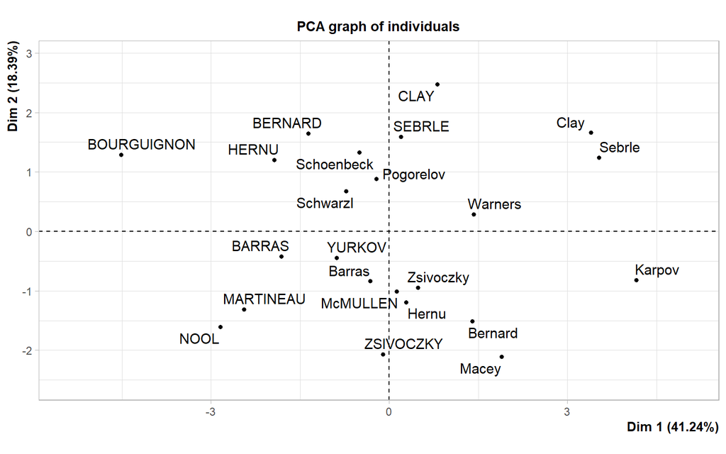

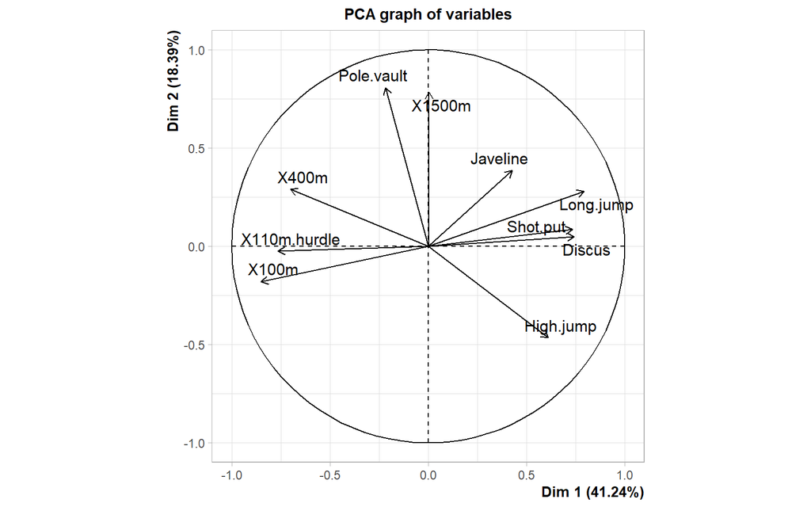

```r
res.pca <-PCA(df, scale.unit = TRUE, graph = TRUE)
```

## Question 6

Show the output list of the function `PCA()`.

```r
print(res.pca)
```

```
## **Results for the Principal Component Analysis (PCA)**
## The analysis was performed on 23 individuals, described by 10 variables
## *The results are available in the following objects:
##
##    name               description
## 1  "$eig"             "eigenvalues"
## 2  "$var"             "results for the variables"
## 3  "$var$coord"       "coord. for the variables"
## 4  "$var$cor"         "correlations variables - dimensions"
## 5  "$var$cos2"        "cos2 for the variables"
## 6  "$var$contrib"     "contributions of the variables"
## 7  "$ind"             "results for the individuals"
## 8  "$ind$coord"       "coord. for the individuals"
## 9  "$ind$cos2"        "cos2 for the individuals"
## 10 "$ind$contrib"     "contributions of the individuals"
## 11 "$call"            "summary statistics"
## 12 "$call$centre"     "mean of the variables"
## 13 "$call$ecart.type" "standard error of the variables"
## 14 "$call$row.w"      "weights for the individuals"
## 15 "$call$col.w"      "weights for the variables"
```

We ll use the `factoextra` `R` package to help in the interpretation of PCA. No matter what function you decide to use [`stats::prcomp()`, `FactoMiner::PCA()`, `ade4::dudi.pca()`, `ExPosition::epPCA()`], you can easily extract and visualize the results of `PCA` using `R` functions provided in the `factoextra` package. These functions include:

- `get_eigenvalue`: Extract the eigenvalues/variances of principal components
- `fviz_eig`: Visualize the eigenvalues
- `get_pca_ind`, `get_pca_var`: Extract the results for individuals and variables, respectively. `fviz_pca_ind`, `fviz_pca_var`: Visualize the results individuals and variables, respectively.
- `fviz_pca_biplot` : Make a biplot of individuals and variables. Next, we ll illustrate each of these functions.

## Question 7

Examine the eigenvalues to determine the number of principal components to be considered using the function `get_eigenvalue()` from the `factoextra` package

```r
get_eigenvalue(res.pca)
```

```
##        eigenvalue variance.percent cumulative.variance.percent
## Dim.1   4.1242133        41.242133                    41.24213
## Dim.2   1.8385309        18.385309                    59.62744
## Dim.3   1.2391403        12.391403                    72.01885
## Dim.4   0.8194402         8.194402                    80.21325
## Dim.5   0.7015528         7.015528                    87.22878
## Dim.6   0.4228828         4.228828                    91.45760
## Dim.7   0.3025817         3.025817                    94.48342
## Dim.8   0.2744700         2.744700                    97.22812
## Dim.9   0.1552169         1.552169                    98.78029
## Dim.10  0.1219710         1.219710                   100.00000
```

Unfortunately, there is no well-accepted objective way to decide how many principal components are enough. This will depend on the specific field of application and the specific data set. Here we recall three possible options:

- Kaiser criteria : An eigenvalue > 1 indicates that PCs account for more variance than accounted by one of the original variables in standardized data. This is commonly used as a cutoff point for which PCs are retained. This holds true only when the data are standardized.
- Limit the number of component to that number that accounts for a certain fraction of the total variance. For example, if you are satisfied with 70% of the total variance explained then use the number of components to achieve that.
- Look at a Scree Plot, which is the plot of eigenvalues ordered from largest to the smallest. The number of component is determined at the point, beyond which the remaining eigenvalues are all relatively small and of comparable size

## Question 8

Show the scree plot using the function `fviz_eig()` and discuss how many principal components are enough.

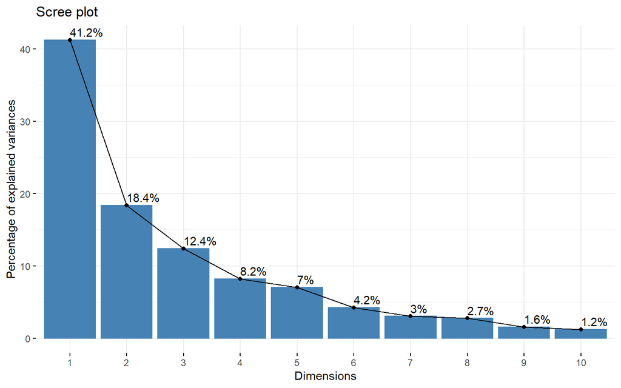

```r
fviz_eig(res.pca,addlabels = TRUE)
```

The correlation between a variable and a principal component (PC) is used as the coordinates of the variable on the PC. The representation of variables differs from the plot of the observations: The observations are represented by their projections, but the variables are represented by their correlations.

## Question 9

Plot the correlation circle using the fviz_pca_var function.

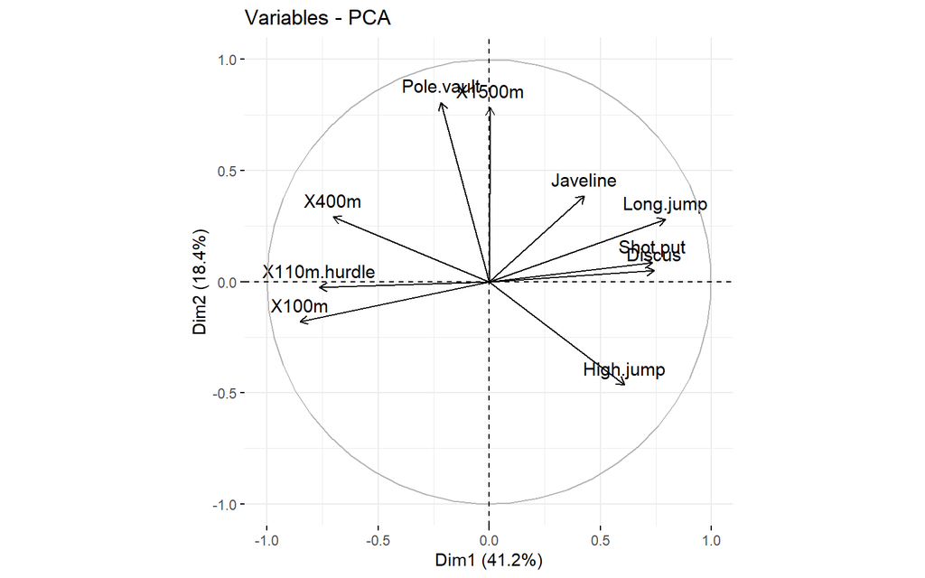

```r
fviz_pca_var(res.pca)
```

The quality of representation of the variables on factor map is called cos2 (square cosine, squared coordinates).

## Question 10

Print the quality of representation of the variables and plot them.

```r
var <- get_pca_var(res.pca)
var
```

```
## Principal Component Analysis Results for variables
##  ===================================================
##   Name       Description
## 1 "$coord"   "Coordinates for the variables"
## 2 "$cor"     "Correlations between variables and dimensions"
## 3 "$cos2"    "Cos2 for the variables"
## 4 "$contrib" "contributions of the variables"
```

```r
head(var$cos2)
```

```
##                  Dim.1        Dim.2      Dim.3        Dim.4      Dim.5
## X100m        0.7235641 0.0321836641 0.09093628 0.0011271597 0.03780845
## Long.jump    0.6307229 0.0788806285 0.03630798 0.0133147506 0.05436203
## Shot.put     0.5386279 0.0072938636 0.26790749 0.0165041211 0.06190783
## High.jump    0.3722025 0.2164242070 0.10895622 0.0208947375 0.16216747
## X400m        0.4922473 0.0842034209 0.08039091 0.1856106269 0.01079698
## X110m.hurdle 0.5838873 0.0006121077 0.20149984 0.0002854712 0.05027463
```

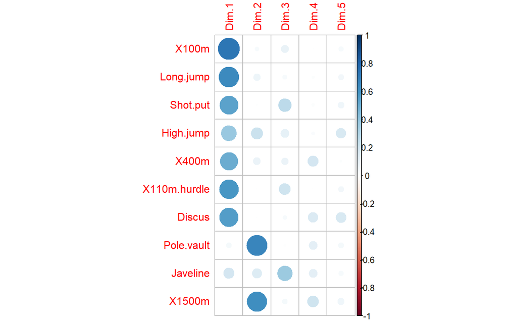

```r
library("corrplot")
corrplot(var$cos2)
```

## Question 11

Color variables by their `cos2` values using the argument `col.var`

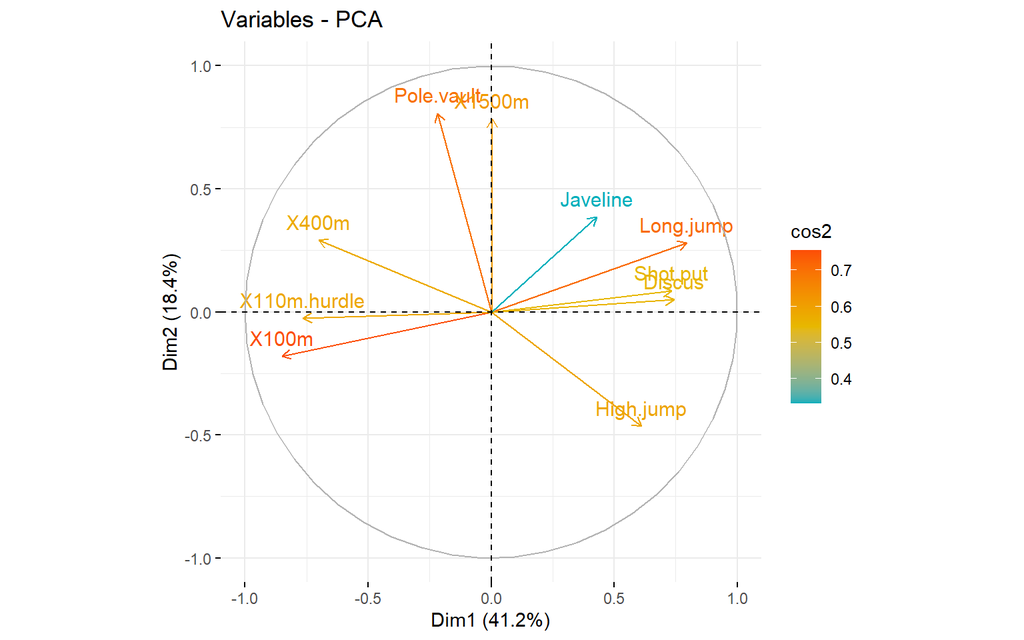

```r
fviz_pca_var(res.pca, col.var = "cos2",
             gradient.cols = c("#00AFBB", "#E7B800", "#FC4E07"))
```

## Question 12

Apply the function `dimdesc()` from `FactoMineR`, to show a dimension description and identify the most significantly associated variables with first principal components

```r
res.desc <- dimdesc(res.pca, axes = c(1,2), proba = 0.05)
res.desc
```

```
## $Dim.1
##
## Link between the variable and the continuous variables (R-square)
## =================================================================================
##              correlation      p.value
## Long.jump      0.7941806 6.059893e-06
## Discus         0.7432090 4.842563e-05
## Shot.put       0.7339127 6.723102e-05
## High.jump      0.6100840 1.993677e-03
## Javeline       0.4282266 4.149192e-02
## X400m         -0.7016034 1.910387e-04
## X110m.hurdle  -0.7641252 2.195812e-05
## X100m         -0.8506257 2.727129e-07
##
## $Dim.2
##
## Link between the variable and the continuous variables (R-square)
## =================================================================================
##            correlation      p.value
## Pole.vault   0.8074511 3.205016e-06
## X1500m       0.7844802 9.384747e-06
## High.jump   -0.4652142 2.529390e-02
```

## Question 13

Extract the results for individuals using the function `get_pca_ind()`

```r
ind <- get_pca_ind(res.pca)
ind
```

```
## Principal Component Analysis Results for individuals
##  ===================================================
##   Name       Description
## 1 "$coord"   "Coordinates for the individuals"
## 2 "$cos2"    "Cos2 for the individuals"
## 3 "$contrib" "contributions of the individuals"
```

## Question 14

Produce the graph of individuals using `fviz_pca_ind()` and color individuals by their `cos2` values.

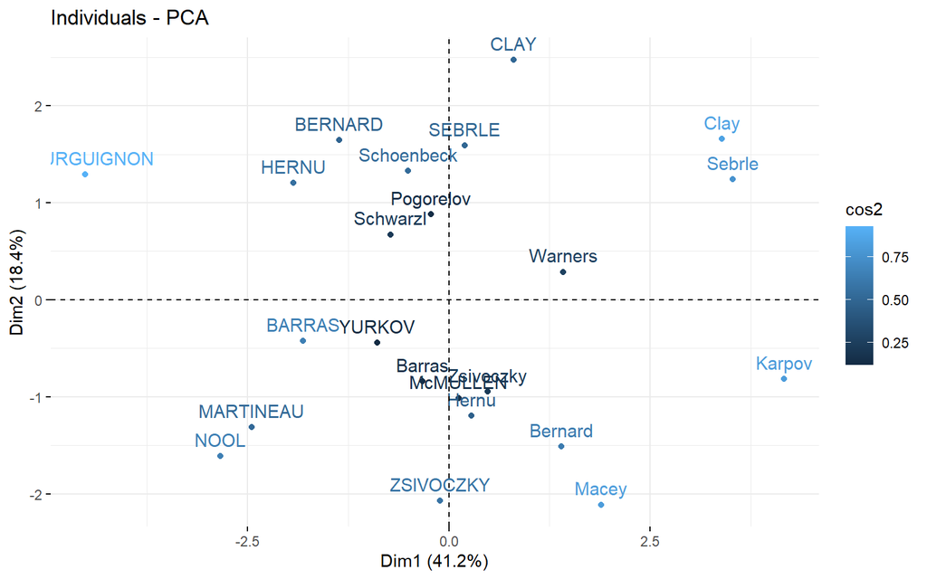

```r
fviz_pca_ind(res.pca, col.ind = "cos2")
```

## Question 15

Change the point size according the cos2 of the corresponding individuals

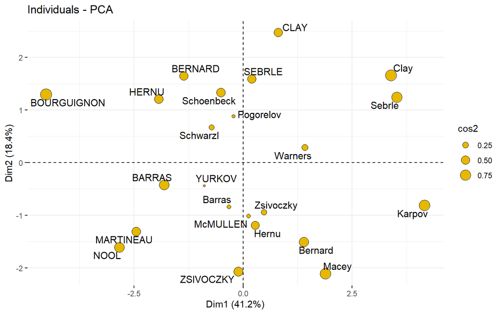

```r
fviz_pca_ind(res.pca, pointsize = "cos2",
             pointshape = 21, fill = "#E7B800",
             repel = TRUE # Avoid text overlapping (slow if many points)
             )
```

## Question 16

Specify supplementary individuals and variables, the function `PCA()`

```r
res.pca <- PCA(decathlon2, ind.sup = 24:27,
               quanti.sup = 11:12, quali.sup = 13, graph=FALSE)
```

## Question 17

Predict results (coordinates, correlation and cos2) for the supplementary quantitative variable.

```r
res.pca$quanti.sup
```

```
## $coord
##             Dim.1       Dim.2      Dim.3       Dim.4       Dim.5
## Rank   -0.7014777 -0.24519443 -0.1834294  0.05575186 -0.07382647
## Points  0.9637075  0.07768262  0.1580225 -0.16623092 -0.03114711
##
## $cor
##             Dim.1       Dim.2      Dim.3       Dim.4       Dim.5
## Rank   -0.7014777 -0.24519443 -0.1834294  0.05575186 -0.07382647
## Points  0.9637075  0.07768262  0.1580225 -0.16623092 -0.03114711
##
## $cos2
##            Dim.1       Dim.2      Dim.3      Dim.4        Dim.5
## Rank   0.4920710 0.060120310 0.03364635 0.00310827 0.0054503477
## Points 0.9287322 0.006034589 0.02497110 0.02763272 0.0009701427
```

## Question 18

Predict results for the supplementary individuals (ind.sup) and visualize all individuals (active and supplementary ones).

```r
res.pca$ind.sup
```

```
## $coord
##              Dim.1       Dim.2      Dim.3      Dim.4       Dim.5
## KARPOV   0.7947206  0.77951227 -1.6330203  1.7242283 -0.75070396
## WARNERS -0.3864645 -0.12159237 -1.7387332 -0.7063341 -0.03230011
## Nool    -0.5591306  1.97748871 -0.4830358 -2.2784526 -0.25461493
## Drews   -1.1092038  0.01741477 -3.0488182 -1.5343468 -0.32642192
##
## $cos2
##              Dim.1        Dim.2      Dim.3      Dim.4        Dim.5
## KARPOV  0.05104677 4.911173e-02 0.21553730 0.24028620 0.0455487744
## WARNERS 0.02422707 2.398250e-03 0.49039677 0.08092862 0.0001692349
## Nool    0.02897149 3.623868e-01 0.02162236 0.48108780 0.0060077529
## Drews   0.09207094 2.269527e-05 0.69560547 0.17617609 0.0079736753
##
## $dist
##   KARPOV  WARNERS     Nool    Drews
## 3.517470 2.482899 3.284943 3.655527
```

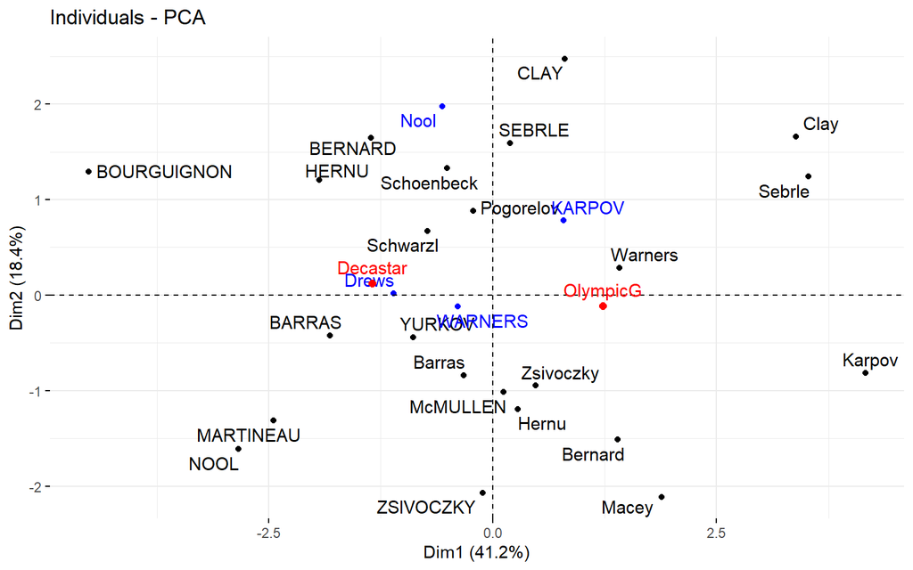

```r
p <- fviz_pca_ind(res.pca, col.ind.sup = "blue", repel = TRUE)
p <- fviz_add(p, res.pca$quali.sup$coord, color = "red")
p
```

## Question 19

Color individuals by the supplementary qualitative variable (columns 13 corresponding to the type of competitions), using the argument habillage to specify the index of the supplementary qualitative variable.

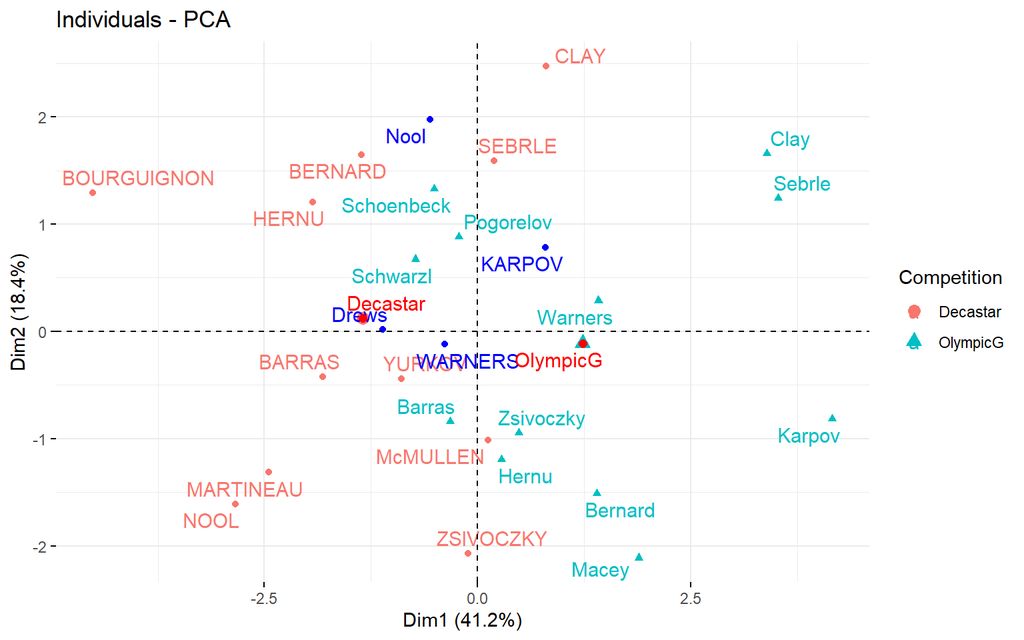

```r
p <- fviz_pca_ind(res.pca, col.ind.sup = "blue", repel = TRUE,habillage = 13)
p <- fviz_add(p, res.pca$quali.sup$coord, color = "red", repel = TRUE)
p
```

## Question 20

Interpret and analyze the obtained results.

# Example 2 : IRIS Data

## Question 1

Download the csv iris dataset and import it into `R`. Show the correlation matrix of the quantitative variables.

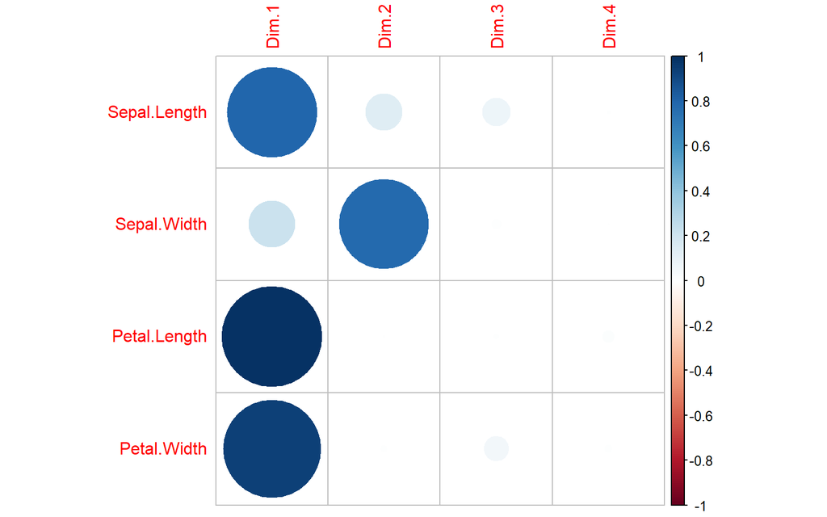

```r
#iris
# The variable Species (index = 5) is removed
# before PCA analysis
iris.pca <- PCA(iris[,-5], graph = FALSE)

var2 <- get_pca_var(iris.pca)
corrplot(var2$cos2)
```

## Question 2

Compare the means and the quartiles of the 3 different flower classes for the 4 different features

```r
summary(iris[,-5])
```

```
##   Sepal.Length    Sepal.Width     Petal.Length    Petal.Width
##  Min.   :4.300   Min.   :2.000   Min.   :1.000   Min.   :0.100
##  1st Qu.:5.100   1st Qu.:2.800   1st Qu.:1.600   1st Qu.:0.300
##  Median :5.800   Median :3.000   Median :4.350   Median :1.300
##  Mean   :5.843   Mean   :3.057   Mean   :3.758   Mean   :1.199
##  3rd Qu.:6.400   3rd Qu.:3.300   3rd Qu.:5.100   3rd Qu.:1.800
##  Max.   :7.900   Max.   :4.400   Max.   :6.900   Max.   :2.500
```

```r
# mean ---> Sepal.Length > Petal.Length > Sepal.Width  > Petal.Width

# 1st Qu.:5.100   1st Qu.:2.800   1st Qu.:1.600   1st Qu.:0.300
```

## Question 3

To explore how the 3 different flower classes are distributed along the 4 different features, visualize them via histograms using the `ggplot` packages through the `geom_histogram` plot.

```r
library(ggplot2)
library(reshape2)

iris2 <- melt(iris, id.vars="Species")
iris2[1:3,]
```

```
##   Species     variable value
## 1  setosa Sepal.Length   5.1
## 2  setosa Sepal.Length   4.9
## 3  setosa Sepal.Length   4.7
```

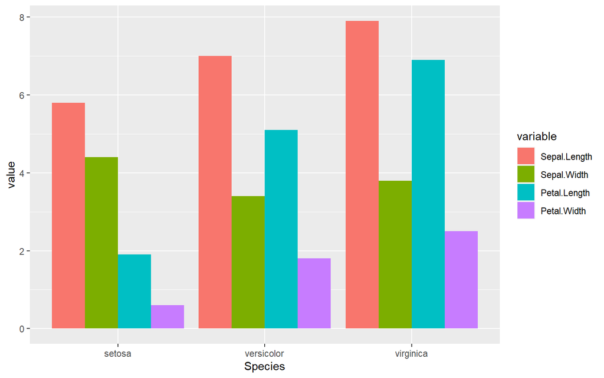

```r
bar1 <- ggplot(data=iris2, aes(x=Species, y=value, fill=variable))
bar1 + geom_histogram(stat="identity", position="dodge")
```

## Question 4

Apply a PCA on the Iris dataset using the `princomp` function and interpret the results

```r
iris.pca <- princomp(iris[-5])
iris.pca
```

```
## Call:
## princomp(x = iris[-5])
##
## Standard deviations:
##    Comp.1    Comp.2    Comp.3    Comp.4
## 2.0494032 0.4909714 0.2787259 0.1538707
##
##  4  variables and  150 observations.
```

```r
summary(iris.pca)
```

```
## Importance of components:
##                           Comp.1     Comp.2     Comp.3      Comp.4
## Standard deviation     2.0494032 0.49097143 0.27872586 0.153870700
## Proportion of Variance 0.9246187 0.05306648 0.01710261 0.005212184
## Cumulative Proportion  0.9246187 0.97768521 0.99478782 1.000000000
```

## Question 5

Using the `factoextra` package plot the following:

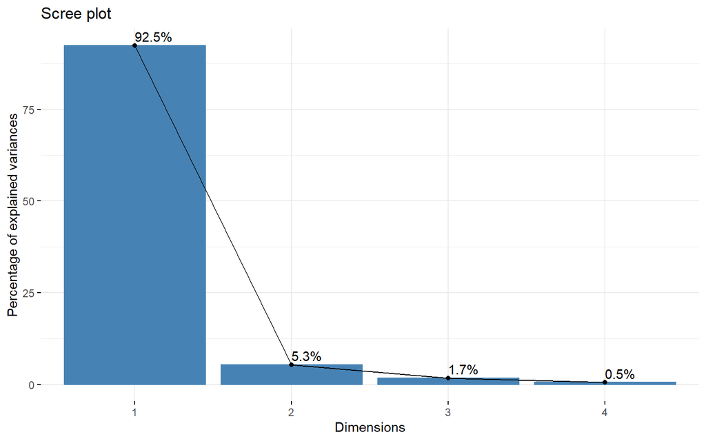

```r
fviz_eig(iris.pca,addlabels = TRUE)
```

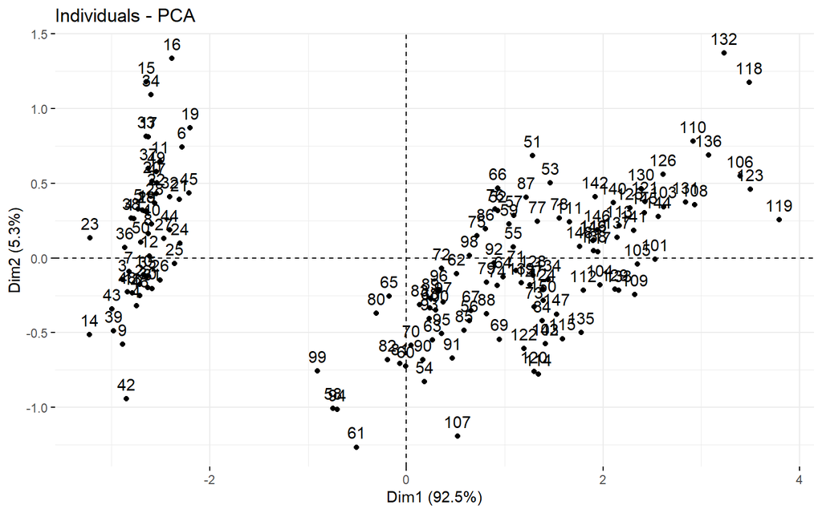

```r
fviz_pca_ind(iris.pca)
```

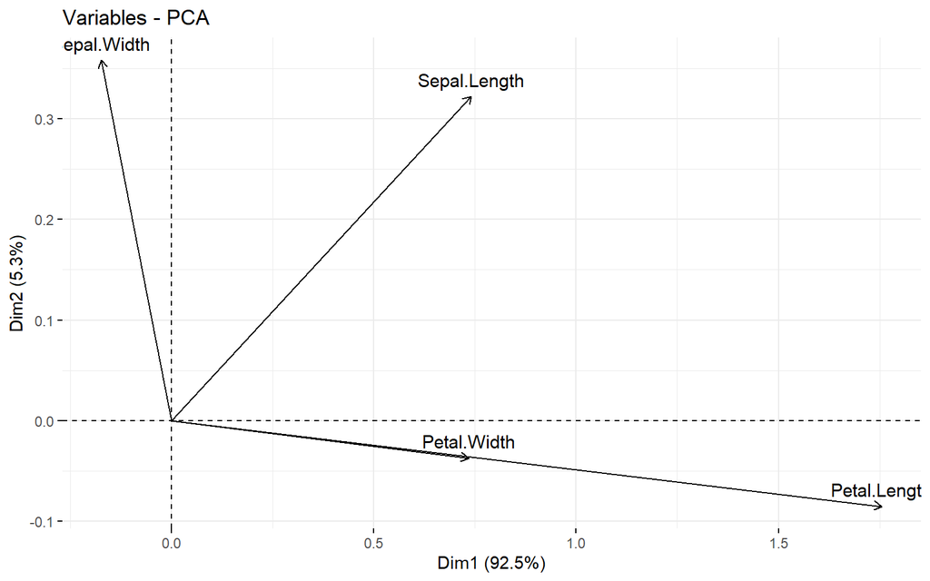

```r
fviz_pca_var(iris.pca)
```

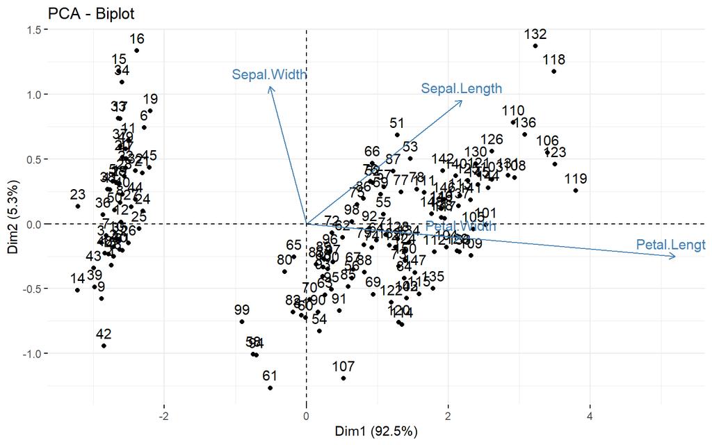

```r
fviz_pca_biplot(iris.pca)
```

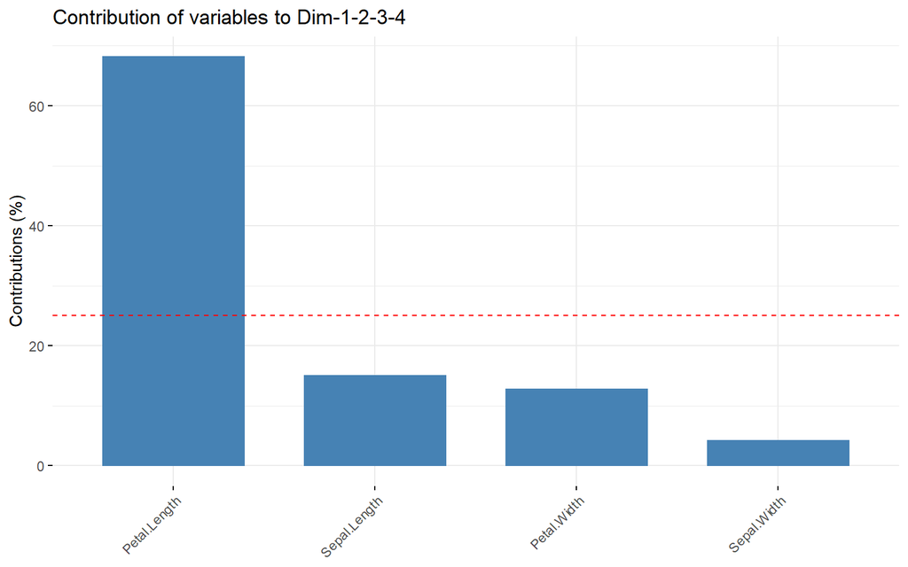

```r
fviz_contrib(iris.pca, choice = "var", axes = 1:4, top = 10)
```

# Example 3 (Extra) : Step-by-step PCA

## Question 1

First step, split the iris dataset into data X and class labels y.

```r
X <- iris[, 1:4]
Y <- iris$Species
```

## Question 2

Scale the 4 features. Store the scaled matrix into a new one (for example, name it X_scaled)

```r
X_scaled=scale(X)
```

## Question 3

Compute the Covariance Matrix of the scaled features (Print the results)

```r
covX=cov(X_scaled)
covX
```

```
##              Sepal.Length Sepal.Width Petal.Length Petal.Width
## Sepal.Length    1.0000000  -0.1175698    0.8717538   0.8179411
## Sepal.Width    -0.1175698   1.0000000   -0.4284401  -0.3661259
## Petal.Length    0.8717538  -0.4284401    1.0000000   0.9628654
## Petal.Width     0.8179411  -0.3661259    0.9628654   1.0000000
```

## Question 4

Perform an eigen decomposition on the covariance matrix. Compute the Eigenvectors and the Eigenvalues (you can use the eigen() function). What do you obtain?

```r
eigen(covX)
```

```
## eigen() decomposition
## $values
## [1] 2.91849782 0.91403047 0.14675688 0.02071484
##
## $vectors
##            [,1]        [,2]       [,3]       [,4]
## [1,]  0.5210659 -0.37741762  0.7195664  0.2612863
## [2,] -0.2693474 -0.92329566 -0.2443818 -0.1235096
## [3,]  0.5804131 -0.02449161 -0.1421264 -0.8014492
## [4,]  0.5648565 -0.06694199 -0.6342727  0.5235971
```

## Question 5

Perform an eigendecomposition of the standardized data based on the correlation matrix.

```r
corX=cor(X_scaled)
eigen(corX)
```

```
## eigen() decomposition
## $values
## [1] 2.91849782 0.91403047 0.14675688 0.02071484
##
## $vectors
##            [,1]        [,2]       [,3]       [,4]
## [1,]  0.5210659 -0.37741762  0.7195664  0.2612863
## [2,] -0.2693474 -0.92329566 -0.2443818 -0.1235096
## [3,]  0.5804131 -0.02449161 -0.1421264 -0.8014492
## [4,]  0.5648565 -0.06694199 -0.6342727  0.5235971
```

## Question 6

Perform an eigendecomposition of the raw data based on the correlation matrix. Compare the obtained results with the previous question.

```r
eigen(cor(X))
```

```
## eigen() decomposition
## $values
## [1] 2.91849782 0.91403047 0.14675688 0.02071484
##
## $vectors
##            [,1]        [,2]       [,3]       [,4]
## [1,]  0.5210659 -0.37741762  0.7195664  0.2612863
## [2,] -0.2693474 -0.92329566 -0.2443818 -0.1235096
## [3,]  0.5804131 -0.02449161 -0.1421264 -0.8014492
## [4,]  0.5648565 -0.06694199 -0.6342727  0.5235971
```

## Question 7

Calculate the individual explained variation and the cumulative explained variation of each principal component. Show the results

```r
iris.pca <- PCA(X)
```

[figure not shown]

[figure not shown]

## Question 8

Plot the individual explained variation. (scree plot)

## Question 9

Construct the projection matrix that will be used to transform the Iris data onto the new feature subspace

## Question 10

Plot the observations on the new feature space. Name the axis PC1 and PC2.

## Question 11

On the same plot, color the observations (the flowers) with respect to their flower classes.